# Part 1 - Exploration

Haneef Ahamed Mohammad

03/12/2021

**IMPORTANT**: code chunks are created for you. Each code chunk has `eval=FALSE` set in the chunk options. You **MUST** change it to be `eval=TRUE` in order for the code chunks to be evaluated when rendering the document.

# Load packages

This assignment will use packages from the `tidyverse` suite.

```r
library(tidyverse)
```

## Reading the small Data Set

```r
df_start <- readr::read_csv('small_train_data.csv', col_names = TRUE)
df_start %>% glimpse()
```

```
## Rows: 125
## Columns: 6
## $ x07      <dbl> 0.11177674, 0.25100882, 0.65946235, 0.94918516, 0.66804925, 0~
## $ x09      <dbl> 0.56766604, 0.04336232, 0.66390665, 0.65207424, 0.78146069, 0~
## $ x10      <dbl> 0.396381547, 0.618260905, 0.048903943, 0.269819648, 0.2235553~
## $ x11      <dbl> 0.58387771, 0.53653216, 0.48976317, 0.30652758, 0.11211528, 0~
## $ x21      <dbl> 0.810788181, 0.736638473, 0.369762516, 0.926768468, 0.7161686~
## $ response <dbl> -0.292184433, 0.693360200, -0.249312839, 0.378085101, 0.74714~
```

## Reading the large dataset for X-variable

```r
train_x <- readr::read_csv("train_input_set_x.csv", col_names = TRUE)
train_x %>% glimpse()
```

```
## Rows: 1,899
## Columns: 44
## $ run_id <dbl> 1, 2, 3, 4, 5, 6, 7, 8, 9, 10, 11, 12, 13, 14, 15, 16, 17, 18, ~
## $ x01    <dbl> 0.985235945, 0.766539206, 0.230160730, 0.004366989, 0.452833469~
## $ x02    <dbl> 0.8133165, 0.4090398, 0.1348584, 0.2153328, 0.4287669, 0.797549~
## $ x03    <dbl> 0.85431883, 0.59294184, 0.94329236, 0.74947991, 0.09339929, 0.7~
## $ x04    <dbl> 0.40689188, 0.65407912, 0.59624660, 0.86524873, 0.02715081, 0.7~
## $ x05    <dbl> 0.78843409, 0.29460688, 0.88023410, 0.46210092, 0.29478054, 0.1~
## $ x06    <dbl> 0.568118821, 0.560441274, 0.416568244, 0.704653992, 0.039929672~
## $ x07    <dbl> 0.2861404, 0.9422601, 0.9588571, 0.3345177, 0.7958649, 0.699955~
## $ x08    <dbl> 0.3879258, 0.3147583, 0.9187132, 0.4178475, 0.3061616, 0.707366~
## $ x09    <dbl> 0.60550075, 0.03512355, 0.79408378, 0.65352400, 0.21140873, 0.0~
## $ x10    <dbl> 0.99715803, 0.90050345, 0.52073711, 0.74925165, 0.16071140, 0.4~
## $ x11    <dbl> 0.23910422, 0.77241094, 0.33454312, 0.41804550, 0.51938061, 0.2~
## $ x12    <dbl> 0.95115757, 0.64939311, 0.03927392, 0.81421180, 0.50300581, 0.6~
```

[output cut: 31 more lines]

## Reading the large dataset for V-variable

```r
train_v <- readr::read_csv("train_input_set_v.csv", col_names = TRUE)
train_v %>% glimpse()
```

```
## Rows: 1,899
## Columns: 42
## $ run_id <dbl> 1, 2, 3, 4, 5, 6, 7, 8, 9, 10, 11, 12, 13, 14, 15, 16, 17, 18, ~
## $ v01    <dbl> 0.60550075, 0.03512355, 0.79408378, 0.65352400, 0.21140873, 0.0~
## $ v02    <dbl> 0.59176441, 0.05360364, 0.78632885, 0.49152356, 0.15821610, 0.0~
## $ v03    <dbl> 0.99866539, 0.74442030, 0.19855145, 0.10180881, 0.16904275, 0.2~
## $ v04    <dbl> 0.51914601, 0.08378037, 0.62221318, 0.49275614, 0.08277755, 0.0~
## $ v05    <dbl> 0.98440052, 0.73504281, 0.27906224, 0.22789122, 0.14089563, 0.3~
## $ v06    <dbl> 0.27761280, 0.17613618, 0.09989673, 0.38340545, 0.20285082, 0.0~
## $ v07    <dbl> 0.72065775, 0.76673777, 0.52718254, 0.68876044, 0.18952144, 0.3~
## $ v08    <dbl> 0.25497542, 0.21544020, 0.20828020, 0.37008161, 0.24295170, 0.0~
## $ v09    <dbl> 0.74392608, 0.79567991, 0.53658142, 0.72114180, 0.17622231, 0.3~
## $ v10    <dbl> 0.25743069, 0.19289445, 0.38850662, 0.38366215, 0.22070718, 0.0~
## $ v11    <dbl> 0.99715803, 0.90050345, 0.52073711, 0.74925165, 0.16071140, 0.4~
## $ v12    <dbl> 0.25743069, 0.19289445, 0.38850662, 0.38366215, 0.22070718, 0.0~
```

[output cut: 29 more lines]

## Reading the large dataset of outputs

```r
train_outputs  <- readr::read_csv('train_outputs.csv', col_names = TRUE)
train_outputs  %>% glimpse()
```

```
## Rows: 1,899
## Columns: 3
## $ run_id   <dbl> 1, 2, 3, 4, 5, 6, 7, 8, 9, 10, 11, 12, 13, 14, 15, 16, 17, 18~
## $ response <dbl> 0.74119845, 0.33409119, 0.53881939, 0.06878022, 0.46564607, 0~
## $ outcome  <chr> "event", "non_event", "event", "event", "non_event", "non_eve~
```

# Preapring data for Regression

```r
ready_x_A <- train_x %>%
  left_join(train_outputs, by = 'run_id') %>%
  select(-run_id, -outcome)

ready_x_A %>% glimpse()
```

```
## Rows: 1,899
## Columns: 44
## $ x01      <dbl> 0.985235945, 0.766539206, 0.230160730, 0.004366989, 0.4528334~
## $ x02      <dbl> 0.8133165, 0.4090398, 0.1348584, 0.2153328, 0.4287669, 0.7975~
## $ x03      <dbl> 0.85431883, 0.59294184, 0.94329236, 0.74947991, 0.09339929, 0~
## $ x04      <dbl> 0.40689188, 0.65407912, 0.59624660, 0.86524873, 0.02715081, 0~
## $ x05      <dbl> 0.78843409, 0.29460688, 0.88023410, 0.46210092, 0.29478054, 0~
## $ x06      <dbl> 0.568118821, 0.560441274, 0.416568244, 0.704653992, 0.0399296~
## $ x07      <dbl> 0.2861404, 0.9422601, 0.9588571, 0.3345177, 0.7958649, 0.6999~
## $ x08      <dbl> 0.3879258, 0.3147583, 0.9187132, 0.4178475, 0.3061616, 0.7073~
## $ x09      <dbl> 0.60550075, 0.03512355, 0.79408378, 0.65352400, 0.21140873, 0~
## $ x10      <dbl> 0.99715803, 0.90050345, 0.52073711, 0.74925165, 0.16071140, 0~
## $ x11      <dbl> 0.23910422, 0.77241094, 0.33454312, 0.41804550, 0.51938061, 0~
## $ x12      <dbl> 0.95115757, 0.64939311, 0.03927392, 0.81421180, 0.50300581, 0~
## $ x13      <dbl> 0.74115583, 0.52151850, 0.01774069, 0.43711821, 0.39755305, 0~
```

[output cut: 31 more lines]

```r
ready_v_A <- train_v %>%
  left_join(train_outputs, by = 'run_id') %>%
  select(-run_id, -outcome)

ready_v_A %>% glimpse()
```

```
## Rows: 1,899
## Columns: 42
## $ v01      <dbl> 0.60550075, 0.03512355, 0.79408378, 0.65352400, 0.21140873, 0~
## $ v02      <dbl> 0.59176441, 0.05360364, 0.78632885, 0.49152356, 0.15821610, 0~
## $ v03      <dbl> 0.99866539, 0.74442030, 0.19855145, 0.10180881, 0.16904275, 0~
## $ v04      <dbl> 0.51914601, 0.08378037, 0.62221318, 0.49275614, 0.08277755, 0~
## $ v05      <dbl> 0.98440052, 0.73504281, 0.27906224, 0.22789122, 0.14089563, 0~
## $ v06      <dbl> 0.27761280, 0.17613618, 0.09989673, 0.38340545, 0.20285082, 0~
## $ v07      <dbl> 0.72065775, 0.76673777, 0.52718254, 0.68876044, 0.18952144, 0~
## $ v08      <dbl> 0.25497542, 0.21544020, 0.20828020, 0.37008161, 0.24295170, 0~
## $ v09      <dbl> 0.74392608, 0.79567991, 0.53658142, 0.72114180, 0.17622231, 0~
## $ v10      <dbl> 0.25743069, 0.19289445, 0.38850662, 0.38366215, 0.22070718, 0~
## $ v11      <dbl> 0.99715803, 0.90050345, 0.52073711, 0.74925165, 0.16071140, 0~
## $ v12      <dbl> 0.25743069, 0.19289445, 0.38850662, 0.38366215, 0.22070718, 0~
## $ v13      <dbl> 0.974760511, 0.973723716, 0.998414906, 0.698134370, 0.0089954~
```

[output cut: 29 more lines]

# Preparing data for Classification

```r
ready_x_B <- train_x %>%
  left_join(train_outputs, by = 'run_id') %>%
  select(-run_id, -response) %>%
  mutate(outcome = factor(outcome, levels = c("event", "non_event")))

ready_x_B %>% glimpse()
```

```
## Rows: 1,899
## Columns: 44
## $ x01     <dbl> 0.985235945, 0.766539206, 0.230160730, 0.004366989, 0.45283346~
## $ x02     <dbl> 0.8133165, 0.4090398, 0.1348584, 0.2153328, 0.4287669, 0.79754~
## $ x03     <dbl> 0.85431883, 0.59294184, 0.94329236, 0.74947991, 0.09339929, 0.~
## $ x04     <dbl> 0.40689188, 0.65407912, 0.59624660, 0.86524873, 0.02715081, 0.~
## $ x05     <dbl> 0.78843409, 0.29460688, 0.88023410, 0.46210092, 0.29478054, 0.~
## $ x06     <dbl> 0.568118821, 0.560441274, 0.416568244, 0.704653992, 0.03992967~
## $ x07     <dbl> 0.2861404, 0.9422601, 0.9588571, 0.3345177, 0.7958649, 0.69995~
## $ x08     <dbl> 0.3879258, 0.3147583, 0.9187132, 0.4178475, 0.3061616, 0.70736~
## $ x09     <dbl> 0.60550075, 0.03512355, 0.79408378, 0.65352400, 0.21140873, 0.~
## $ x10     <dbl> 0.99715803, 0.90050345, 0.52073711, 0.74925165, 0.16071140, 0.~
## $ x11     <dbl> 0.23910422, 0.77241094, 0.33454312, 0.41804550, 0.51938061, 0.~
## $ x12     <dbl> 0.95115757, 0.64939311, 0.03927392, 0.81421180, 0.50300581, 0.~
## $ x13     <dbl> 0.74115583, 0.52151850, 0.01774069, 0.43711821, 0.39755305, 0.~
```

[output cut: 31 more lines]

```r
ready_v_B <- train_v %>%
  left_join(train_outputs, by = 'run_id') %>%
  select(-run_id, -response) %>%
  mutate(outcome = factor(outcome, levels = c("event", "non_event")))

ready_v_B %>% glimpse()
```

```
## Rows: 1,899
## Columns: 42
## $ v01     <dbl> 0.60550075, 0.03512355, 0.79408378, 0.65352400, 0.21140873, 0.~
## $ v02     <dbl> 0.59176441, 0.05360364, 0.78632885, 0.49152356, 0.15821610, 0.~
## $ v03     <dbl> 0.99866539, 0.74442030, 0.19855145, 0.10180881, 0.16904275, 0.~
## $ v04     <dbl> 0.51914601, 0.08378037, 0.62221318, 0.49275614, 0.08277755, 0.~
## $ v05     <dbl> 0.98440052, 0.73504281, 0.27906224, 0.22789122, 0.14089563, 0.~
## $ v06     <dbl> 0.27761280, 0.17613618, 0.09989673, 0.38340545, 0.20285082, 0.~
## $ v07     <dbl> 0.72065775, 0.76673777, 0.52718254, 0.68876044, 0.18952144, 0.~
## $ v08     <dbl> 0.25497542, 0.21544020, 0.20828020, 0.37008161, 0.24295170, 0.~
## $ v09     <dbl> 0.74392608, 0.79567991, 0.53658142, 0.72114180, 0.17622231, 0.~
## $ v10     <dbl> 0.25743069, 0.19289445, 0.38850662, 0.38366215, 0.22070718, 0.~
## $ v11     <dbl> 0.99715803, 0.90050345, 0.52073711, 0.74925165, 0.16071140, 0.~
## $ v12     <dbl> 0.25743069, 0.19289445, 0.38850662, 0.38366215, 0.22070718, 0.~
## $ v13     <dbl> 0.974760511, 0.973723716, 0.998414906, 0.698134370, 0.00899540~
```

[output cut: 29 more lines]

# Exploartion for small dataset

Visually check for missing values using the visdat package for the small dataset

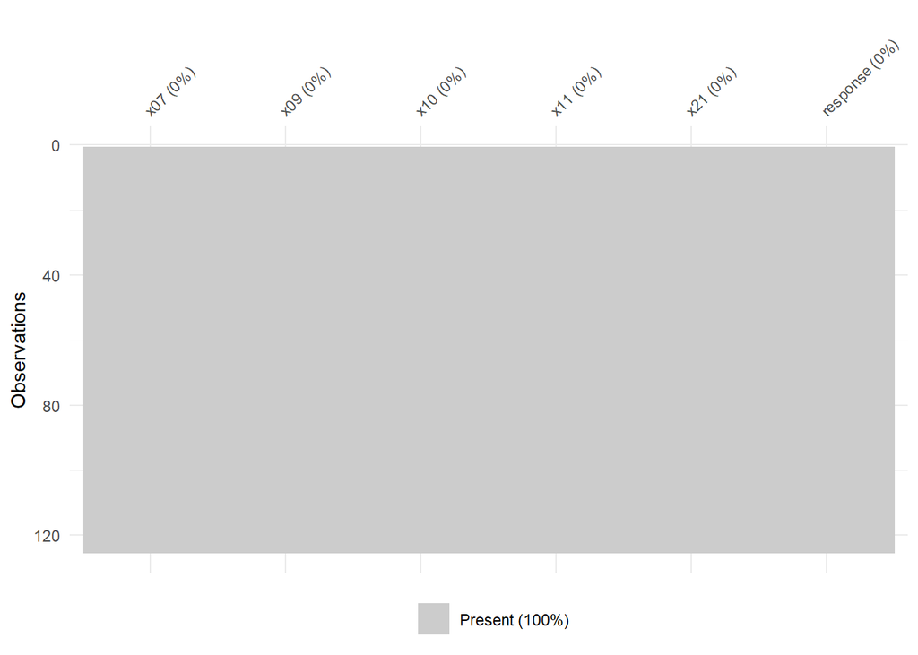

```r
visdat::vis_miss(df_start)
```

Visualizing missing values for the large dataset

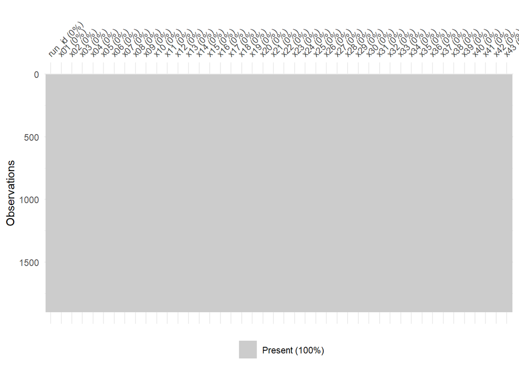

```r
visdat::vis_miss(train_x)
```

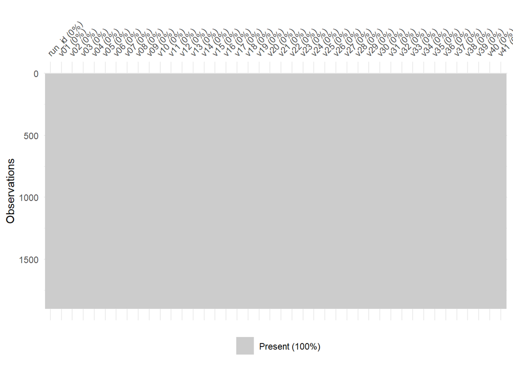

```r
visdat::vis_miss(train_v)
```

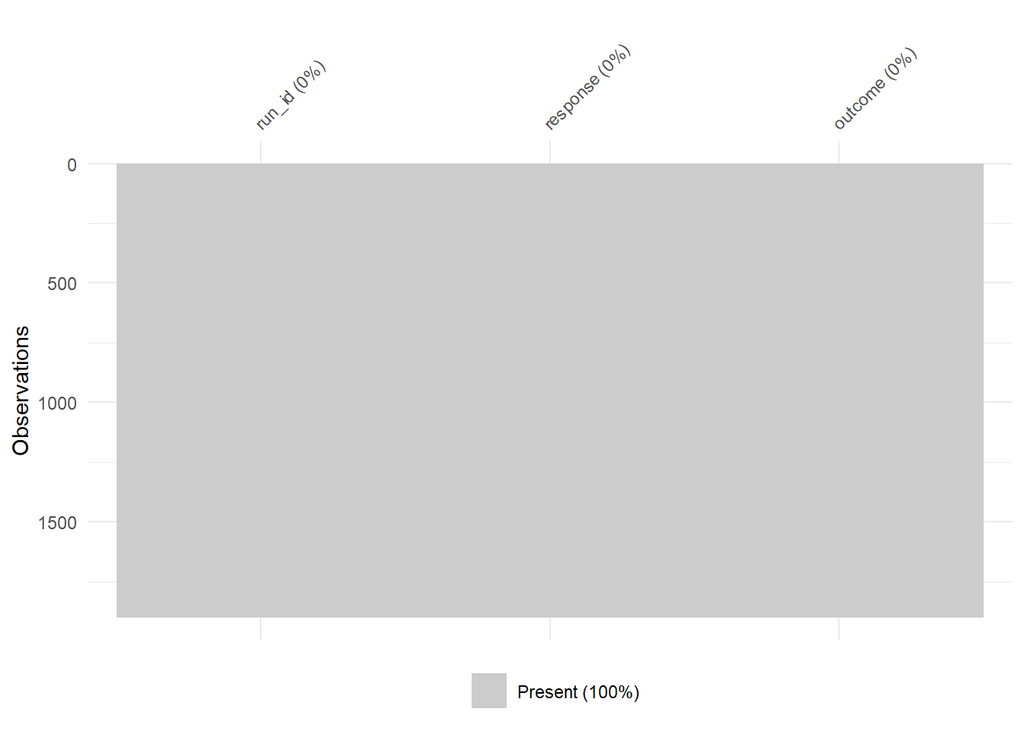

```r
visdat::vis_miss(train_outputs)
```

Visualizing datatypes for the small dataset

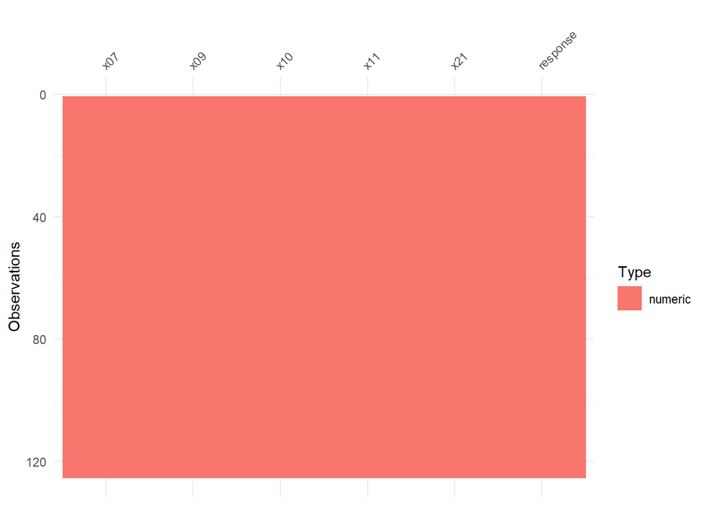

```r
visdat::vis_dat(df_start)
```

Check the number of unique variable for the small dataset

```r
df_start %>% purrr::map_dbl(n_distinct)
```

```
##      x07      x09      x10      x11      x21 response
##      125      125      125      125      125      125
```

## Distributions of the inputs – the “x-variables” for Small data set

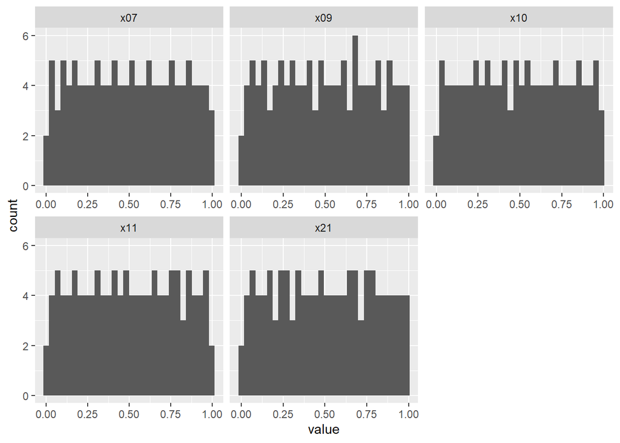

```r
df_start %>%
  tibble::rowid_to_column() %>%
  pivot_longer(cols = !c('rowid',"response")) %>%
  ggplot(mapping = aes(x=value))+
  geom_histogram()+
  facet_wrap(~name,scales = "free_x")
```

## relationships between the continuous output and the “x-variable” for small dataset

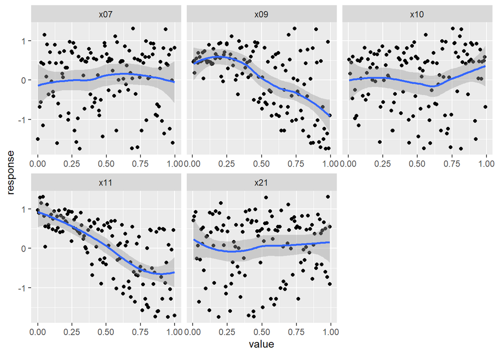

```r
df_start %>%
  tibble::rowid_to_column() %>%
  pivot_longer(cols = !c('rowid',"response")) %>%
  ggplot(mapping = aes(x=value, y=response))+
  geom_point()+
  geom_smooth()+
  facet_wrap(~name,scales = "free_x")
```

## Co-relation between inputs for small dataset

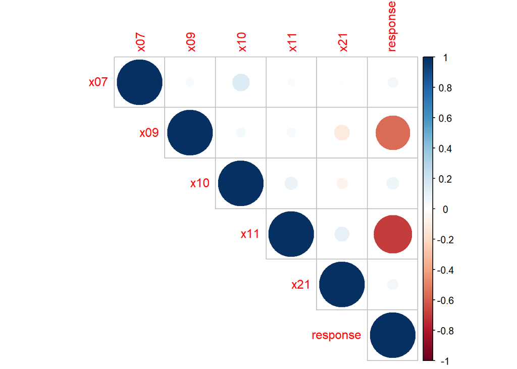

```r
df_start %>% cor() %>% corrplot::corrplot(type = "upper")
```

# Exploration for large Dataset

### Visualizing datatype for the large dataset

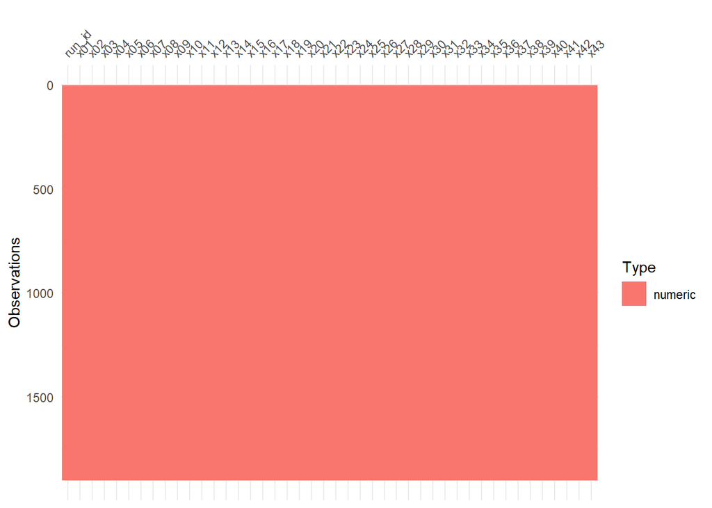

```r
visdat::vis_dat(train_x)
```

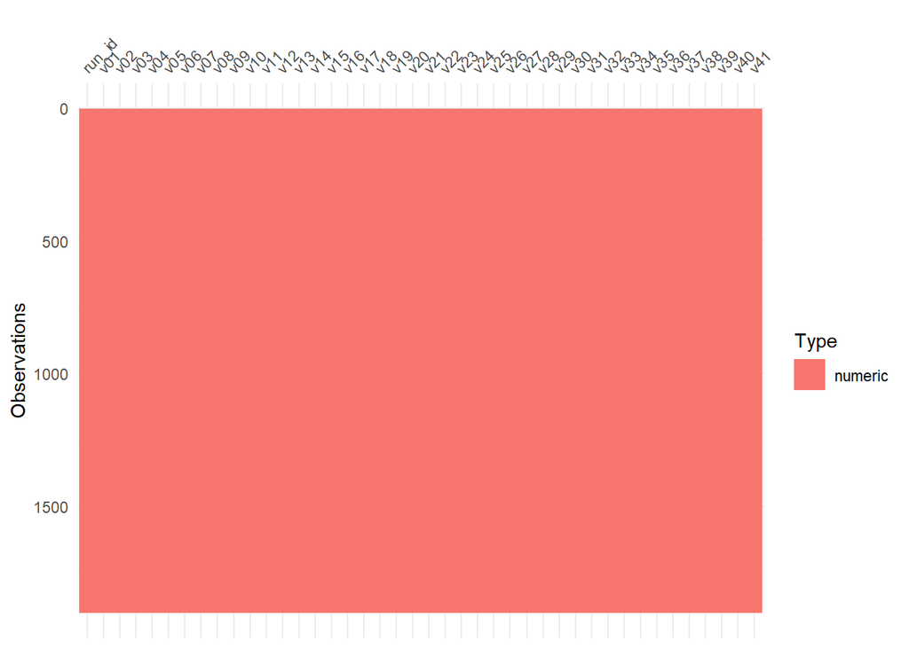

```r
visdat::vis_dat(train_v)
```

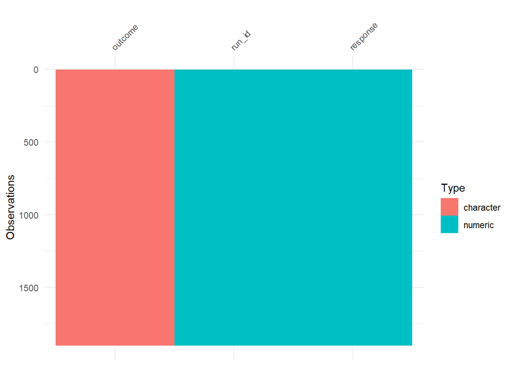

```r
visdat::vis_dat(train_outputs)
```

Check the number of unique variable for the large dataset

```r
train_x %>% purrr::map_dbl(n_distinct)
```

```
## run_id    x01    x02    x03    x04    x05    x06    x07    x08    x09    x10
##   1899   1899   1899   1899   1899   1899   1899   1899   1899   1899   1899
##    x11    x12    x13    x14    x15    x16    x17    x18    x19    x20    x21
##   1899   1899   1899   1899   1899   1899   1899   1899   1899   1899   1899
##    x22    x23    x24    x25    x26    x27    x28    x29    x30    x31    x32
##   1899   1899   1899   1899   1899   1899   1899   1899   1899   1899   1899
##    x33    x34    x35    x36    x37    x38    x39    x40    x41    x42    x43
##   1899   1899   1899   1899   1899   1899   1899   1899   1899   1899   1899
```

```r
train_v %>% purrr::map_dbl(n_distinct)
```

```
## run_id    v01    v02    v03    v04    v05    v06    v07    v08    v09    v10
##   1899   1899   1899   1899   1899   1899   1899   1899   1899   1899   1899
##    v11    v12    v13    v14    v15    v16    v17    v18    v19    v20    v21
##   1899   1899   1899   1899   1899   1899   1899   1899   1899   1899   1899
##    v22    v23    v24    v25    v26    v27    v28    v29    v30    v31    v32
##   1899   1899   1899   1899   1899   1899   1899   1899   1899   1899   1899
##    v33    v34    v35    v36    v37    v38    v39    v40    v41
##   1899   1899   1899   1899   1899   1899   1899   1899   1899
```

```r
train_outputs %>% purrr::map_dbl(n_distinct)
```

```
##   run_id response  outcome
##     1899     1898        2
```

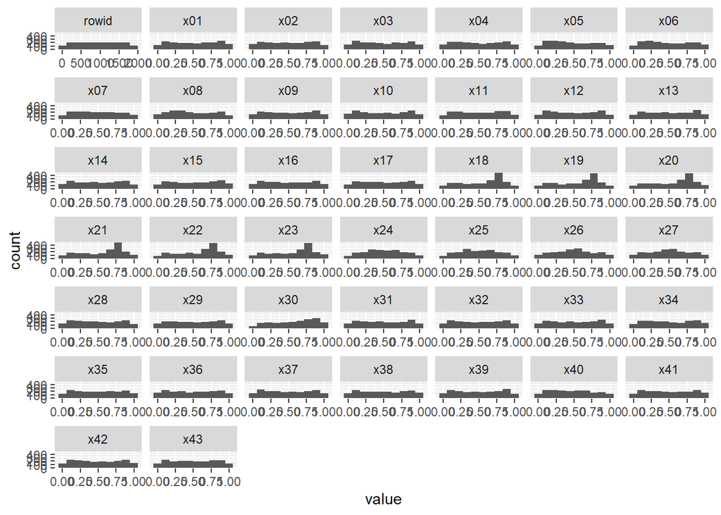

```r
train_x %>%
  tibble::rowid_to_column() %>%
  pivot_longer(cols = !c('run_id')) %>%
  ggplot(mapping = aes(x=value))+
  geom_histogram(bins = 10)+
  facet_wrap(~name,scales = "free_x")
```

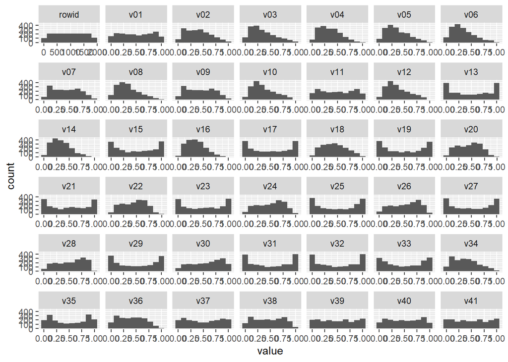

```r
train_v %>%
  tibble::rowid_to_column() %>%
  pivot_longer(cols = !c('run_id')) %>%
  ggplot(mapping = aes(x=value))+
  geom_histogram(bins = 10)+
  facet_wrap(~name,scales = "free_x")
```

## Relationships between the continuous output and the “x-variable”

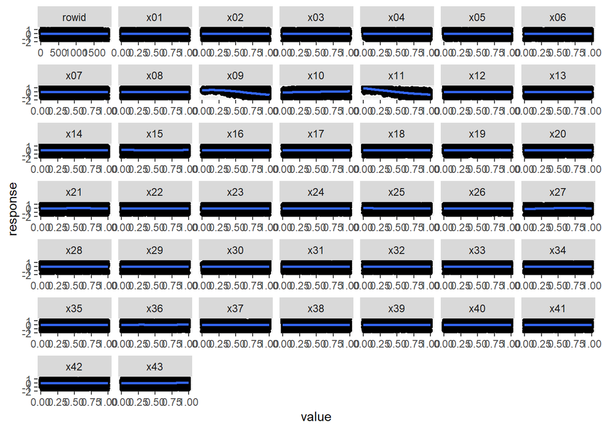

```r
ready_x_A %>%
  tibble::rowid_to_column() %>%
  pivot_longer(cols = !c("response")) %>%
  ggplot(mapping = aes(x=value, y=response))+
  geom_point()+
  geom_smooth()+
  facet_wrap(~name,scales = "free_x")
```

## Relationships between the continuous output and the “V-variable”

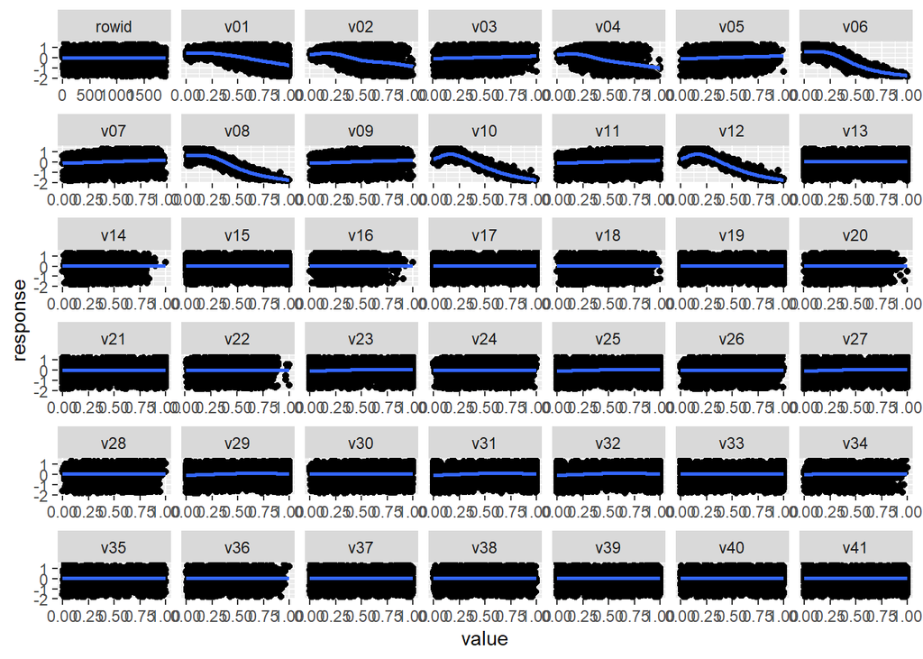

```r
ready_v_A %>%
  tibble::rowid_to_column() %>%
  pivot_longer(cols = !c("response")) %>%
  ggplot(mapping = aes(x=value, y=response))+
  geom_point()+
  geom_smooth()+
  facet_wrap(~name,scales = "free_x")
```

# Input vs binary outcome for x-variable

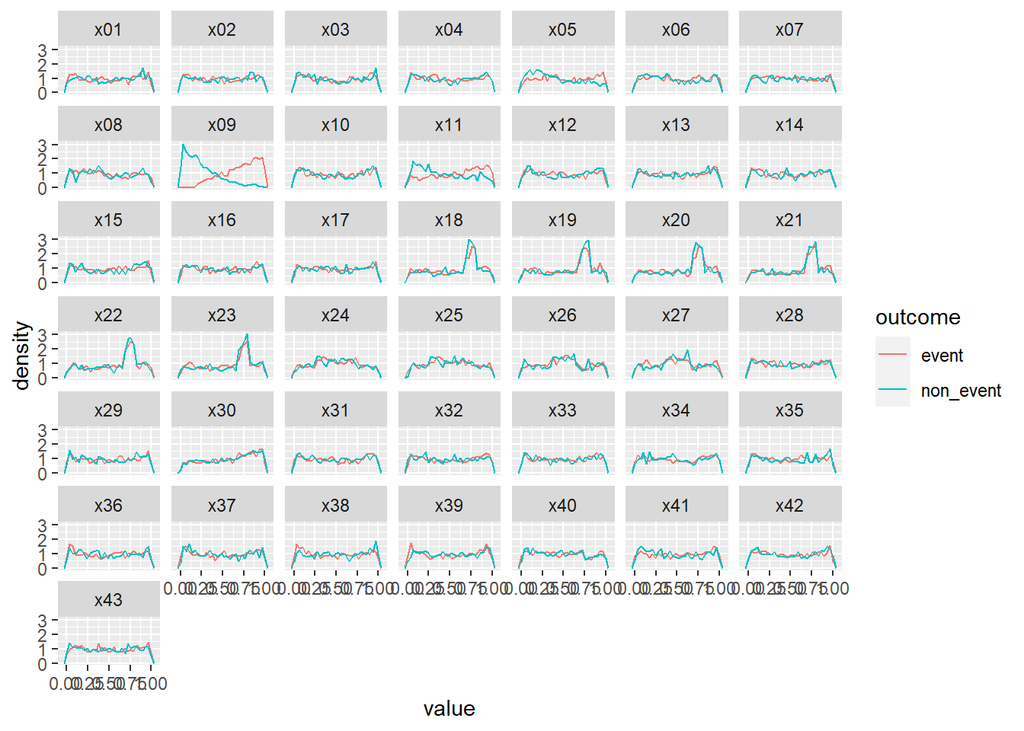

```r
train_x %>%
  left_join(train_outputs, by = 'run_id') %>%
  pivot_longer(!c('run_id', 'response', 'outcome')) %>%
  ggplot(aes(x=value, color = outcome)) +
  geom_freqpoly(aes(y=stat(density))) +
  facet_wrap(~name)
```

# Input vs binary outcome for v-variable

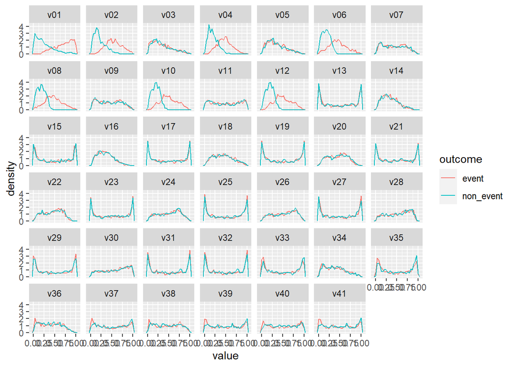

```r
train_v %>%
  left_join(train_outputs, by = 'run_id') %>%
  pivot_longer(!c('run_id', 'response', 'outcome')) %>%
  ggplot(aes(x=value, color = outcome)) +
  geom_freqpoly(aes(y=stat(density))) +
  facet_wrap(~name)
```

# Distribution of Outputs dataset

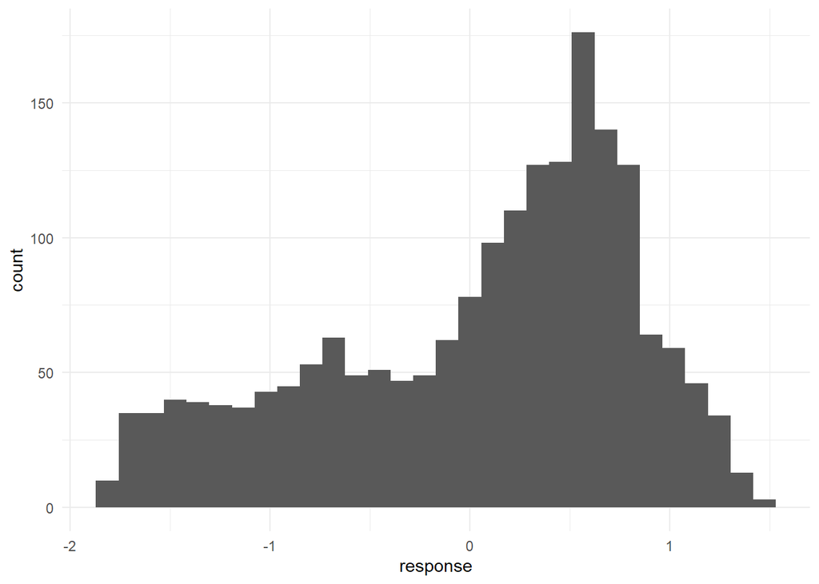

```r
train_outputs %>%
  ggplot(mapping = aes(x = response)) +
  geom_histogram(bins = 30) +
  theme_minimal()
```

Check the count

```r
train_outputs %>% count(outcome)
```

```
## # A tibble: 2 x 2
##   outcome       n
##   <chr>     <int>
## 1 event      1048
## 2 non_event   851
```

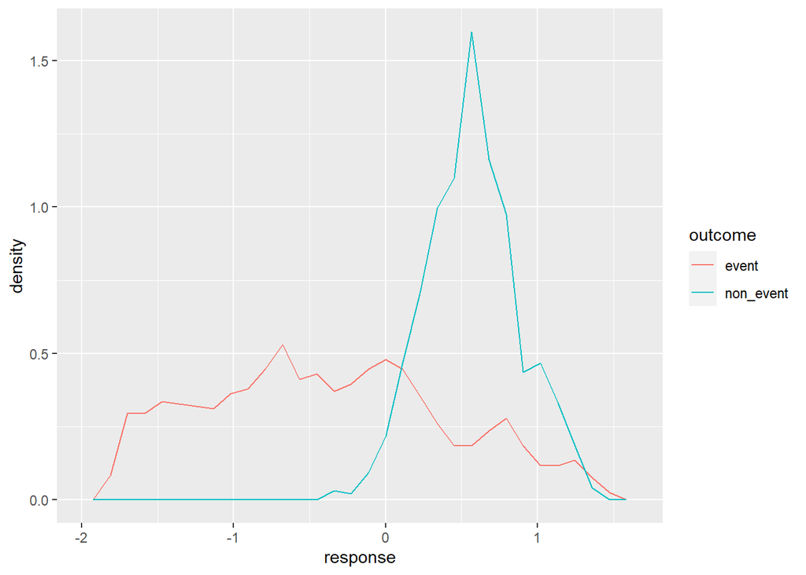

```r
train_outputs %>%
  ggplot(aes(x=response, color = outcome)) +
  geom_freqpoly(aes(y=stat(density)))
```